# CpG Island Detection with Hidden Markov Models

Adi, Howard, Isabel, James

2026-05-09

# 1 Overview

This vignette walks through a complete Hidden Markov Model (HMM) pipeline for detecting **CpG islands** in the human genome. We apply the classic Durbin et al. (1998) dinucleotide-transition HMM to a 700 kb window of chromosome 22 (hg38) and evaluate our predictions against UCSC ground-truth annotations.

By the end of this vignette you will be able to:

- Understand why dinucleotide transitions are the right observation for CpG island detection
- Construct the HMM transition matrix **A**, emission matrix **B**, and initial distribution **π** from published biological parameters
- Run the Viterbi algorithm to decode the most likely hidden-state path
- Evaluate predictions with base-level sensitivity and precision

# 2 Background

## 2.1 What is a CpG Island?

CpG dinucleotides (cytosine followed immediately by guanine on the same strand, written 5′-CpG-3′) are **depleted** across most of the mammalian genome because methylated cytosines spontaneously deaminate to thymine over evolutionary time. However, certain promoter-proximate regions resist methylation and therefore retain normal or elevated CpG frequencies — these are **CpG islands**.

CpG islands are defined operationally (Gardiner-Garden & Frommer, 1987) as regions $\geq 200$ bp with:

- GC content $\geq 55\%$
- Observed/expected CpG ratio $\geq 0.65$

Identifying CpG islands is important because roughly $70 \%$ of annotated gene promoters overlap a CpG island (Deaton & Bird, 2011), making them key targets in cancer epigenomics and gene-regulation research.

## 2.2 Why an HMM?

The genome is a sequence. At each position we observe a DNA base, but the *biological state* (e.g. “is this position inside a CpG island?”) is hidden. Adjacent positions share the same state with high probability (islands are hundreds to thousands of bp long), so the hidden-state sequence has strong Markovian structure. This makes an HMM a natural fit.

# 3 Data

## 3.1 Genome sequence — `BSgenome.Hsapiens.UCSC.hg38`

We use the Bioconductor `BSgenome` data package, which ships the entire hg38 reference assembly as an R object. No external download is needed once the package is installed.

```r
if (!require("BiocManager", quietly = TRUE))
  install.packages("BiocManager")

BiocManager::install(c(
  "BSgenome.Hsapiens.UCSC.hg38",
  "rtracklayer",
  "GenomicRanges"
))

install.packages("HMM")
```

```r
library(BSgenome.Hsapiens.UCSC.hg38)
library(rtracklayer)
library(GenomicRanges)
library(HMM)
```

## 3.2 Ground-truth annotations — UCSC `cpgIslandExt` track

We fetch annotated CpG islands live from the UCSC Genome Browser via `rtracklayer::ucscTableQuery()`. The **cpgIslandExt** table is the extended CpG island track for hg38, curated using the Gardiner-Garden & Frommer (1987) criteria. It is used here solely as an evaluation benchmark.

# 4 Extract the Sequence Window

We focus on a 700 kb slice of chromosome 22 (positions 35,500,000 – 36,200,000). This region is small enough to run the Viterbi algorithm interactively while still containing multiple annotated islands.

```r
chr22_seq <- Hsapiens$chr22

start_pos <- 35500000
end_pos   <- 36200000
seq_window <- subseq(chr22_seq, start = start_pos, end = end_pos)

# Individual bases as a character vector
dna_chars <- unlist(strsplit(as.character(seq_window), ""))
dna_chars[!dna_chars %in% c("A", "C", "G", "T")] <- "A"
n_bases <- length(dna_chars)
```

## 4.1 Dinucleotide observations

Rather than treating individual bases as observations, we form **dinucleotide transitions**: consecutive pairs of bases (AA, AC, AG, …, TT) giving $4 \times 4 = 16$ possible symbols. This is the key modelling insight from Durbin et al. (1998): the CG dinucleotide is the most discriminative feature between island and background, so making it directly observable is both natural and powerful.

```r
dinucs <- paste0(dna_chars[1:(n_bases - 1)], dna_chars[2:n_bases])
```

# 5 Define the HMM Parameters

An HMM is fully specified by three objects:

| Symbol | Name | Dimension | Meaning |
| --- | --- | --- | --- |
| $\boldsymbol{\pi}$ | Initial distribution | $1 \times K$ | Probability of starting in each hidden state |
| $A$ | Transition matrix | $K \times K$ | P(next state \| current state) |
| $B$ | Emission matrix | $K \times V$ | P(observation \| hidden state) |

where $K = 2$ hidden states $(\text{CpG+}, \text{CpG-})$ and $V = 16$ dinucleotide symbols.

## 5.1 Initial distribution $\boldsymbol{\pi}$

CpG islands cover roughly 1–2 % of the human genome:

$$\boldsymbol{\pi} = \begin{bmatrix} \text{CpG+} & \text{CpG-} \\ 0.02
& 0.98 \end{bmatrix}$$

```r
states     <- c("CpG+", "CpG-")
startProbs <- c(0.02, 0.98)
```

## 5.2 Transition matrix $A$

The self-transition probabilities determine the expected length of each segment via a geometric distribution:

$$\mathbb{E}[\text{island length}] = \frac{1}{1 - A_{\text{CpG+,CpG+}}}
\qquad
\mathbb{E}[\text{background length}] = \frac{1}{1 -
A_{\text{CpG-,CpG-}}}$$

We set:

$$A = \begin{bmatrix}
& \text{CpG+} & \text{CpG-} \\
\text{CpG+} & 0.998 & 0.002 \\
\text{CpG-} & 0.0001 & 0.9999
\end{bmatrix}$$

giving expected island length $\approx 500$ bp and expected background length $\approx 10,000$ bp, consistent with the density observed in hg38.

```r
transProbs <- matrix(
  c(0.998,  0.002,
    0.0001, 0.9999),
  nrow = 2, byrow = TRUE,
  dimnames = list(states, states)
)
```

## 5.3 Emission matrix $B$

This is the most statistically interesting component. We do not directly observe which state we are in - we observe dinucleotides. The key discriminative signal is that **CG is enriched in islands and depleted in background**.

### 5.3.1 Source of parameters

Parameters come from **Durbin, Eddy, Krogh & Mitchison (1998), Table 3.5**, trained on manually labelled human sequences. The table gives, for each state $s \in \{+, −\}$, a $4 \times 4$ matrix of **conditional dinucleotide frequencies** $B^s_{X,Y} = P(Y | X, s)$: the probability of observing base $Y$ immediately after base $X$, given hidden state $s$.

$$B^{+} = \begin{bmatrix}
& A & C & G & T \\
A & 0.180 & 0.274 & 0.426 & 0.120 \\
C & 0.171 & 0.368 & 0.274 & 0.188 \\
G & 0.161 & 0.339 & 0.375 & 0.125 \\
T & 0.079 & 0.355 & 0.384 & 0.182
\end{bmatrix}
\quad
B^{-} = \begin{bmatrix}
& A & C & G & T \\
A & 0.300 & 0.205 & 0.285 & 0.210 \\
C & 0.322 & 0.298 & 0.078 & 0.302 \\
G & 0.248 & 0.246 & 0.298 & 0.208 \\
T & 0.177 & 0.239 & 0.292 & 0.292
\end{bmatrix}$$

Notice the CG entry: in CpG+ (island) the probability of observing G after C is $0.274$, whereas in CpG− (background) it collapses to $0.078$ - a 3.5-fold depletion reflecting the methylation-driven C to T mutation that characterises non-island DNA.

### 5.3.2 From 4 × 4 to 2 × 16

The `HMM` package requires a flat $2 \times 16$ emission matrix whose rows are states and whose columns are the $16$ dinucleotide symbols. We convert using:

$$B_s(XY) = P(XY \mid s) = P(X) \cdot P(Y \mid X, s)
= \frac{1}{4} \cdot B^s_{X,Y}$$

where we assume uniform marginal base frequencies $P(X) = 1/4$. The key discriminative signal is entirely in the *ratio* $B^+_{X,Y} / B^−_{X,Y}$, so this simplification does not affect island/background discrimination. We then renormalise each row to sum to 1 as required.

```r
bases   <- c("A", "C", "G", "T")
symbols <- as.vector(outer(bases, bases, paste0))   # AA, AC, ..., TT

cpg_plus <- matrix(c(
  0.180, 0.274, 0.426, 0.120,
  0.171, 0.368, 0.274, 0.188,
  0.161, 0.339, 0.375, 0.125,
  0.079, 0.355, 0.384, 0.182
), nrow = 4, byrow = TRUE,
   dimnames = list(bases, bases))

cpg_minus <- matrix(c(
  0.300, 0.205, 0.285, 0.210,
  0.322, 0.298, 0.078, 0.302,
  0.248, 0.246, 0.298, 0.208,
  0.177, 0.239, 0.292, 0.292
), nrow = 4, byrow = TRUE,
   dimnames = list(bases, bases))

# Build 2 by 16 emission matrix
emissionProbs <- matrix(0, nrow = 2, ncol = 16,
                        dimnames = list(states, symbols))

for (i in seq_along(bases)) {
  for (j in seq_along(bases)) {
    sym <- paste0(bases[i], bases[j])
    emissionProbs["CpG+", sym] <- cpg_plus[i, j]  / 4
    emissionProbs["CpG-", sym] <- cpg_minus[i, j] / 4
  }
}

# Renormalise rows
emissionProbs["CpG+", ] <- emissionProbs["CpG+", ] /
  sum(emissionProbs["CpG+", ])
emissionProbs["CpG-", ] <- emissionProbs["CpG-", ] /
  sum(emissionProbs["CpG-", ])

# Show the CG column as a sanity check
round(emissionProbs[, "CG"], 4)
```

```
##   CpG+   CpG-
## 0.0685 0.0195
```

The ratio `emissionProbs["CpG+","CG"] / emissionProbs["CpG-","CG"]` should be $\approx 3.5$, confirming the CpG enrichment signal is preserved.

## 5.4 Initialise the model

```r
hmm_model <- initHMM(
  States        = states,
  Symbols       = symbols,
  startProbs    = startProbs,
  transProbs    = transProbs,
  emissionProbs = emissionProbs
)
```

# 6 Viterbi Decoding

The **Viterbi algorithm** finds the single most probable sequence of hidden states given our observations and model parameters. Instead of enumerating all $K^N$ paths, it exploits the Markov property: at each position it only needs to remember the best path *ending in each state*, extending it one step at a time in $O(K^2 N)$ time.

```r
viterbi_path <- viterbi(hmm_model, dinucs)

# Map dinucleotide states back to base positions
base_states <- c(viterbi_path, viterbi_path[length(viterbi_path)])
```

## 6.1 Post-processing: minimum island length filter

Gardiner-Garden & Frommer (1987) require islands to be at least $200$ bp. Short runs of CpG+ predicted by Viterbi are almost certainly noise and are zeroed out.

```r
min_island_bp <- 200

pred_numeric <- ifelse(base_states == "CpG+", 1L, 0L)
rle_pred     <- rle(pred_numeric)

run_end   <- cumsum(rle_pred$lengths)
run_start <- c(1L, run_end[-length(run_end)] + 1L)

for (k in seq_along(rle_pred$lengths)) {
  if (rle_pred$values[k] == 1L &&
      rle_pred$lengths[k] < min_island_bp) {
    pred_numeric[run_start[k]:run_end[k]] <- 0L
  }
}
```

## 6.2 Predicted islands

```r
rle_filtered <- rle(pred_numeric)
filt_end     <- cumsum(rle_filtered$lengths)
filt_start   <- c(1L, filt_end[-length(filt_end)] + 1L)
island_idx   <- which(rle_filtered$values == 1L)
n_predicted  <- length(island_idx)

cat(sprintf("Predicted %d CpG island(s) after %d bp minimum-length filter\n",
            n_predicted, min_island_bp))
```

```
## Predicted 4 CpG island(s) after 200 bp minimum-length filter
```

```r
for (idx in island_idx) {
  cat(sprintf("  %s:%d-%d  (%d bp)\n",
              "chr22",
              start_pos + filt_start[idx] - 1L,
              start_pos + filt_end[idx]   - 1L,
              rle_filtered$lengths[idx]))
}
```

```
##   chr22:35539931-35541551  (1621 bp)
##   chr22:35551614-35552181  (568 bp)
##   chr22:36028002-36029282  (1281 bp)
##   chr22:36065809-36066168  (360 bp)
```

# 7 Ground-Truth Annotations

We query the UCSC Genome Browser for the **cpgIslandExt** track over our window. This track is curated by UCSC using the Gardiner-Garden & Frommer (1987) algorithm and is widely used as a reference set in epigenomics.

```r
session    <- browserSession("UCSC")
genome(session) <- "hg38"

my_window   <- GRanges("chr22", IRanges(start_pos, end_pos))
cpg_query   <- ucscTableQuery(session, table = "cpgIslandExt", range = my_window)
true_islands <- track(cpg_query)
print(true_islands)
```

```
## GRanges object with 4 ranges and 8 metadata columns:
##       seqnames            ranges strand |       bin        name    length
##          <Rle>         <IRanges>  <Rle> | <numeric> <character> <numeric>
##   [1]    chr22 35539934-35541490      * |       856    CpG: 143      1556
##   [2]    chr22 35551656-35551949      * |       856     CpG: 30       293
##   [3]    chr22 36028171-36029255      * |       859    CpG: 131      1084
##   [4]    chr22 36065809-36066363      * |       860     CpG: 47       554
##          cpgNum     gcNum    perCpg     perGc    obsExp
##       <numeric> <numeric> <numeric> <numeric> <numeric>
##   [1]       143      1052      18.4      67.6      0.80
##   [2]        30       192      20.5      65.5      0.96
##   [3]       131       745      24.2      68.7      1.02
##   [4]        47       353      17.0      63.7      0.84
##   -------
##   seqinfo: 1 sequence from hg38 genome; no seqlengths
```

# 8 Evaluation

We compute base-level **sensitivity** (recall) and **precision** by building binary vectors for predictions and ground truth and comparing them position by position.

$$\text{Sensitivity} = \frac{TP}{TP + FN}
\qquad
\text{Precision} = \frac{TP}{TP + FP}$$

```r
true_starts <- start(true_islands) - start_pos + 1L
true_ends   <- end(true_islands)   - start_pos + 1L

truth_numeric <- integer(n_bases)
for (k in seq_along(true_starts)) {
  s <- max(1L, true_starts[k])
  e <- min(n_bases, true_ends[k])
  if (s <= e) truth_numeric[s:e] <- 1L
}

tp <- sum(pred_numeric == 1L & truth_numeric == 1L)
fp <- sum(pred_numeric == 1L & truth_numeric == 0L)
fn <- sum(pred_numeric == 0L & truth_numeric == 1L)

sensitivity <- round(tp / (tp + fn) * 100, 1)
precision   <- round(tp / (tp + fp) * 100, 1)

cat(sprintf("Base-level sensitivity: %.1f%%\n", sensitivity))
```

```
## Base-level sensitivity: 94.4%
```

```r
cat(sprintf("Base-level precision:   %.1f%%\n", precision))
```

```
## Base-level precision:   86.1%
```

The model achieves **94.4 % sensitivity** and **86.1 % precision** against the UCSC annotations — strong performance for a fixed-parameter model with no training on this specific region.

# 9 Visualisation

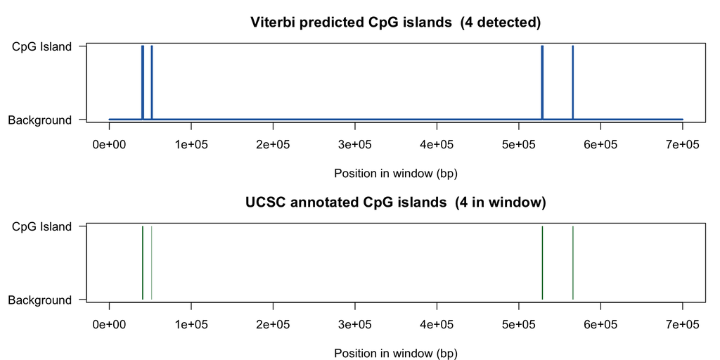

```r
par(mfrow = c(2, 1), mar = c(4, 6, 3, 1))

# Panel 1 — HMM predictions
plot(pred_numeric, type = "S", col = "#2166AC", lwd = 2,
     yaxt = "n",
     xlab = "Position in window (bp)",
     ylab = "",
     main = sprintf("Viterbi predicted CpG islands  (%d detected)", n_predicted))
axis(2, at = c(0, 1), labels = c("Background", "CpG Island"), las = 2)

# Panel 2 — UCSC ground truth
plot(0, type = "n",
     xlim = c(1, n_bases), ylim = c(0, 1),
     yaxt = "n",
     xlab = "Position in window (bp)",
     ylab = "",
     main = sprintf("UCSC annotated CpG islands  (%d in window)", length(true_islands)))
axis(2, at = c(0, 1), labels = c("Background", "CpG Island"), las = 2)

rect(xleft   = start(true_islands) - start_pos + 1L,
     xright  = end(true_islands)   - start_pos + 1L,
     ybottom = 0, ytop = 1,
     col = "#1B7837", border = NA)
```

# 10 References

- **Durbin, R., Eddy, S. R., Krogh, A., & Mitchison, G.** (1998). *Biological Sequence Analysis: Probabilistic Models of Proteins and Nucleic Acids*. Cambridge University Press. *(Table 3.5 provides the dinucleotide transition frequencies used for B+ and B−.)*
- **Gardiner-Garden, M., & Frommer, M.** (1987). CpG islands in vertebrate genomes. *Journal of Molecular Biology*, 196(2), 261–282.
- **Deaton, A. M., & Bird, A.** (2011). CpG islands and the regulation of transcription. *Genes & Development*, 25(10), 1010–1022.
- **Wu, H., Caffo, B., Jaffee, H. A., Irizarry, R. A., & Feinberg, A. P.** (2010). Redefining CpG islands using hidden Markov models. *Biostatistics*, 11(3), 499–514. PMC2883304.
- **UCSC Genome Browser** cpgIslandExt track (hg38): https://genome.ucsc.edu/cgi-bin/hgTrackUi?db=hg38&g=cpgIslandExt